# Homework 4: Causal Inference III + Prediction I

STA 235H

Due on Nov. 4th, 11:59pm

# Task 1: Real Estate Tycoon (40 points)

It’s the beginning of 2030 and imagine you have just been promoted to senior executive at a large real estate company (let’s call it “Sillow”, so we don’t get sued). You want to impress your boss and are looking for ways to improve the performance of your realtor agents. You decide that a positive measure would be that any realtor that has a performance rate lower than 80% during the previous year should attend a mandatory retreat to increase sales.

At the end of the year, you ask your analysts to send you the data. This is what you receive:

- `id`: An id number for each realtor agent.
- `age`: Age of the realtor agent.
- `female`: Binary variable indicating if the realtor is female (1) or not (0).
- `performance`: The performance of the agent in percentage (ranges from 0 to 100) at the end of 2029.
- `retreat`: Binary variable indicating if an agent was assigned or not to the mandatory retreat.
- `sales`: An agent’s final sales for the entire year 2030, in dollars.

```r
sillow <- read.csv("https://raw.githubusercontent.com/maibennett/sta235/main/exampleSite/content/Assignments/Homework/data/hw4/sillow1.csv")
```

### Question 1.1

**In this example, which variable is your running variable? Which one is your treatment variable? Which one is your outcome of interest?**

*Answer: The running variable is the realtor’s performance (%) in 2029, the outcome of interest is sales in 2030, and the treatment variable is whether the realtor gets assigned to the mandatory retreat or not.*

- 100%: Correctly identifies running variable, treatment variable, and outcome of interest.
- 80%: Doesn’t correctly identify one of the previous variables.
- 50%: Doesn’t correctly identify two of the previous variables.
- 20%: Attempts something that has some meaning, but overall incorrect.
- 0%: Any other case.

### Question 1.2

**Create a plot to show whether the assignment rule exists or not. Was assignment to this program based on an arbitrary rule?** *(Note: Remember to label your axis accordingly)*

*Answer: It is based on an arbitrary rule, meaning that the cutoff is set at 80% is arbitrary. Given that the running variable is continuous around the cutoff, and we know the cutoff score, this is a good candidate for an RD. I also check the fact that the threshold rule exists, and it does.*

```
## [1] "Warning: not enough variability in the outcome variable below the threshold"
## [1] "Warning: not enough variability in the outcome variable above the threshold"
```

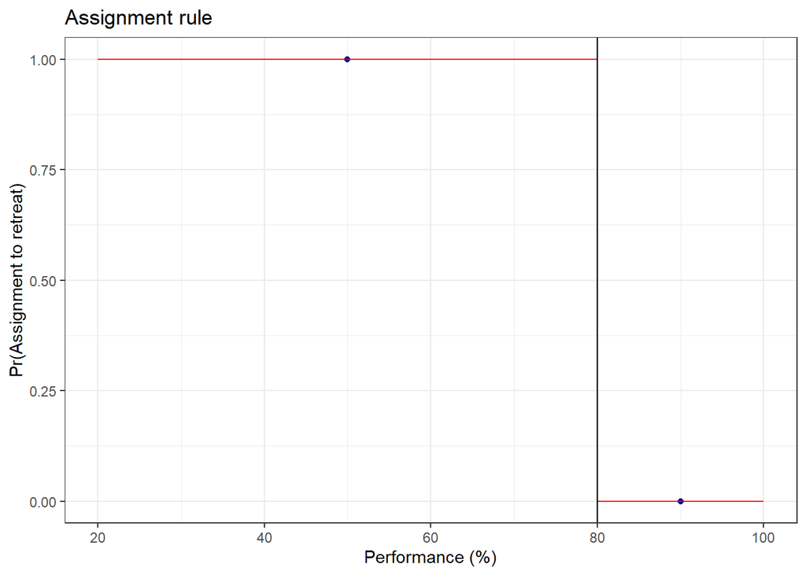

```r
library(tidyverse)
library(rdrobust)
library(rddensity)
library(modelsummary)

rdplot(sillow$retreat, sillow$performance, c = 80, y.label = "Pr(Assignment to retreat)",
       x.label = "Performance (%)", title = "Assignment rule")
```

- 100%: Creates a plot (using rdplot or ggplot) showing a discontinuity in the treatment assignment, and mentions that the 80% cutoff is arbitrary.
- 80%: Creates a plot but doesn’t explain that the treatment assignment is discontinuous.
- 50%: Explains that the treatment assignment needs to be discontinuous, but doesn’t create the right plot.
- 20%: Attempts something that has some meaning, but overall incorrect.
- 0%: Any other case.

### Question 1.3

**We know that our RD is only valid if there is no discontinuity of the potential outcomes at the cutoff, and they are smooth across the threshold.**

**Use one of the covariates in your dataset (you can choose which one) and `rdplot()` and `rdrobust()` to show support for this last assumption. What should you expect to see if the key assumption holds and why? Interpret your results**

*Answer: We want to see that there’s no jump or discontinuity in the covariates across the threshold. As we can see from the `age` variable, the plot doesn’t show a pronounced discontinuity, which is also something we see when we estimate the discontinuity at the cutoff, which is not significant at conventional levels.*

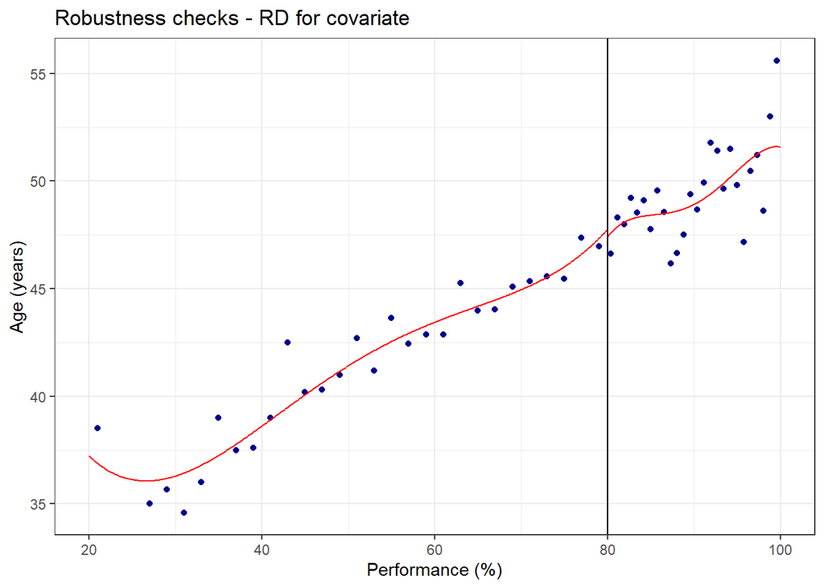

```r
rdplot(sillow$age, sillow$performance, c = 80, y.label = "Age (years)",
       x.label = "Performance (%)", title = "Robustness checks - RD for covariate")
```

```r
summary(rdrobust(sillow$age, sillow$performance, c = 80))
```

```
## [1] "Mass points detected in the running variable."
## Call: rdrobust
##
## Number of Obs.                 1200
## BW type                       mserd
## Kernel                   Triangular
## VCE method                       NN
##
## Number of Obs.                  681          519
## Eff. Number of Obs.             144          166
## Order est. (p)                    1            1
## Order bias  (q)                   2            2
## BW est. (h)                   4.665        4.665
## BW bias (b)                   7.157        7.157
## rho (h/b)                     0.652        0.652
## Unique Obs.                     627          451
##
## =============================================================================
##         Method     Coef. Std. Err.         z     P>|z|      [ 95% C.I. ]
## =============================================================================
##   Conventional    -0.141     1.437    -0.098     0.922    [-2.958 , 2.676]
##         Robust         -         -    -0.060     0.952    [-3.520 , 3.311]
## =============================================================================
```

- 100%: Creates a plot (using rdplot or ggplot) and estimates the discontinuity at the cutoff (using rdrobust) for one covariate (could be age or female). Explains that we expect to see no discontinuity and shows that in their results.
- 80%: Creates a plot (using rdplot or ggplot) and estimates the discontinuity at the cutoff (using rdrobust) for one covariate, but doesn’t correctly interpret the results/ Correctly interpret the results, but either the plot or the rdrobust output is missing.
- 50%: Creates a plot/rdrobust table, but it’s incorrect (doesn’t use a covariate). Correctly intrepets the plot/table.
- 20%: Attempts something that has some meaning, but overall incorrect.
- 0%: Any other case.

### Question 1.4

**Estimate a causal effect of this program using a (1) parametric approach (linear regression using the whole sample), and (2) nonparametric approach (using rdrobust).** **a) What is the estimand you are estimating here? b) Do your results differ between both models? Why? c) Which one do you prefer and why?**

*Note: For estimating the RD under a parametric approach, remember to create the `distance` variable we saw in class!*

*Answer: Using a parametric approach, we find a estimated LATE of $56,750 in sales. This means that for realtors with a performance of 80% there is an estimated average increase in their sales of $57k due to retreat attendance. When we use a nonparametric approach, we find a much larger effect of $120,000 increase for those at the cutoff that went to the retreat vs those that did not.*

*Both models differ because we are using different assumptions in terms of bandwidth (we are using the complete sample in the first case, and only a limited sample within the bandwidth for the second approach), and also on terms of the functions we are using to fit the model. I would prefer the second approach, because it’s not as sensitive to observations that are far away from the cutoff (which can be very different to the ones at the cutoff). Also, it incorporates additional flexibility.*

```r
sillow <- sillow %>% mutate(distance = performance - 80) # Create the distance variable

# Parametric approach
summary(lm(sales ~ distance + retreat + distance*retreat, data = sillow))
```

```
##
## Call:
## lm(formula = sales ~ distance + retreat + distance * retreat,
##     data = sillow)
##
## Residuals:
##     Min      1Q  Median      3Q     Max
## -223790  -44858     111   41428  239910
##
## Coefficients:
##                       Estimate Std. Error t value Pr(>|t|)
## (Intercept)          2014836.4     5390.0 373.807   <2e-16 ***
## distance               15236.6      578.3  26.349   <2e-16 ***
## retreatTRUE            56749.4     6732.7   8.429   <2e-16 ***
## distance:retreatTRUE     409.3      617.8   0.662    0.508
## ---
## Signif. codes:  0 '***' 0.001 '**' 0.01 '*' 0.05 '.' 0.1 ' ' 1
##
## Residual standard error: 65600 on 1196 degrees of freedom
## Multiple R-squared:  0.9068, Adjusted R-squared:  0.9066
## F-statistic:  3880 on 3 and 1196 DF,  p-value: < 2.2e-16
```

```r
# Nonparametric approach
summary(rdrobust(sillow$sales, sillow$performance, c = 80))
```

```
## [1] "Mass points detected in the running variable."
## Call: rdrobust
##
## Number of Obs.                 1200
## BW type                       mserd
## Kernel                   Triangular
## VCE method                       NN
##
## Number of Obs.                  681          519
## Eff. Number of Obs.             255          279
## Order est. (p)                    1            1
## Order bias  (q)                   2            2
## BW est. (h)                   8.113        8.113
## BW bias (b)                  12.450       12.450
## rho (h/b)                     0.652        0.652
## Unique Obs.                     627          451
##
## =============================================================================
##         Method     Coef. Std. Err.         z     P>|z|      [ 95% C.I. ]
## =============================================================================
##   Conventional-120135.926 13937.670    -8.620     0.000[-147453.257 , -92818.594]
##         Robust         -         -    -7.245     0.000[-154728.363 , -88837.774]
## =============================================================================
```

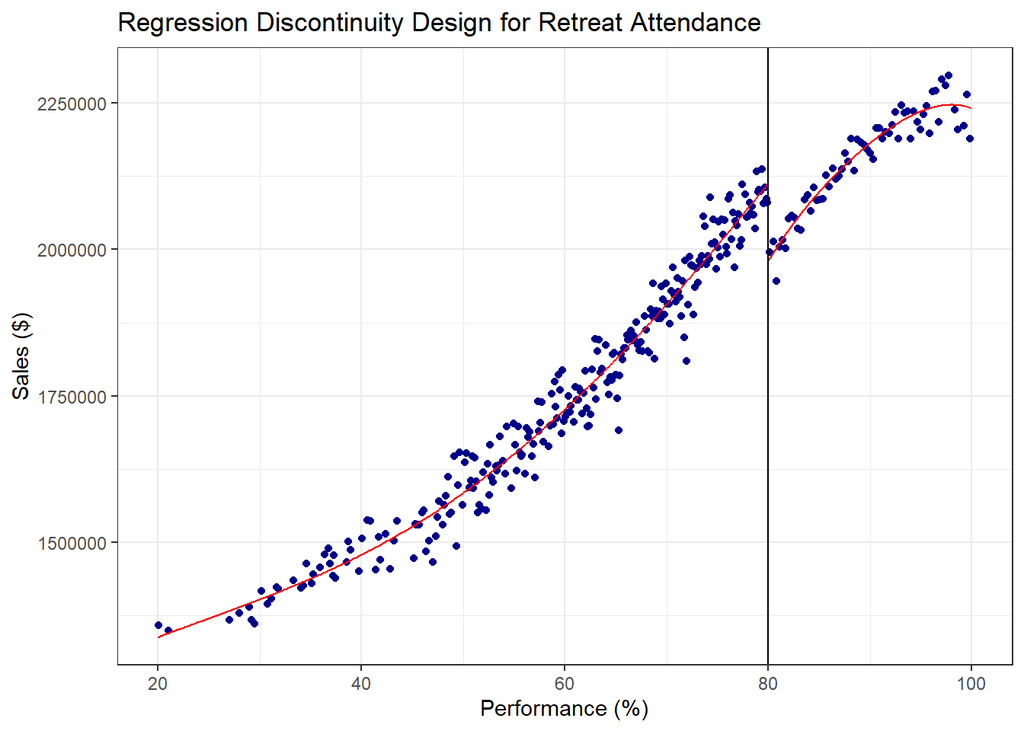

```r
rdplot(sillow$sales, sillow$performance, c = 80, y.label = "Sales ($)",
       x.label = "Performance (%)", title = "Regression Discontinuity Design for Retreat Attendance")
```

- 100%: Correctly fits the parametric model using lm() and an interaction model, and correctly fits the nonparametric model using rdrobust. Interprets the coefficients for treatment correctly. Identifies that the estimand in both cases is a LATE, and that it’s very different for both models, correctly giving some ideas of why (i.e. nonparametric vs linear model, sample used for estimation, kernel). Provides a plausible reason of why they choose rdrobust over lm.
- 80%: Has issues with one of the following: (i) doesn’t fit the right parametric model (forgets interaction), (ii) doesn’t identify that the estimand is a LATE, (iii) doesn’t provide a reasonable idea of why both estimates are different, (iv) doesnt’provide a plausible reason for choosing one over another.
- 50%: Has issues with two of the following: (i) doesn’t fit the right parametric model (forgets interaction), (ii) doesn’t identify that the estimand is a LATE, (iii) doesn’t provide a reasonable idea of why both estimates are different, (iv) doesnt’provide a plausible reason for choosing one over another.
- 20%: Attempts something that has some meaning, but overall incorrect.
- 0%: Any other case.

### Question 1.5

**You have heard through the grapevine that realtors actually think the retreat is fun and useful, so most of them actually want to attend. You are now concerned that this might imply that employees are manipulating their performance score so they are just under the cutoff. What robustness check could you conduct to see if this is true? Show an appropriate plot and explain whether this would be an issue or not.**

*Answer: If employees can manipulate their score so it’s just under 80%, then we would see some bunching right under the cutoff. We can check for the density at the cutoff for this.*

*As we can see from the plot below, there is no discontinuity in the density across the threshold, so this means that probably we should not worry about manipulation in this case.*

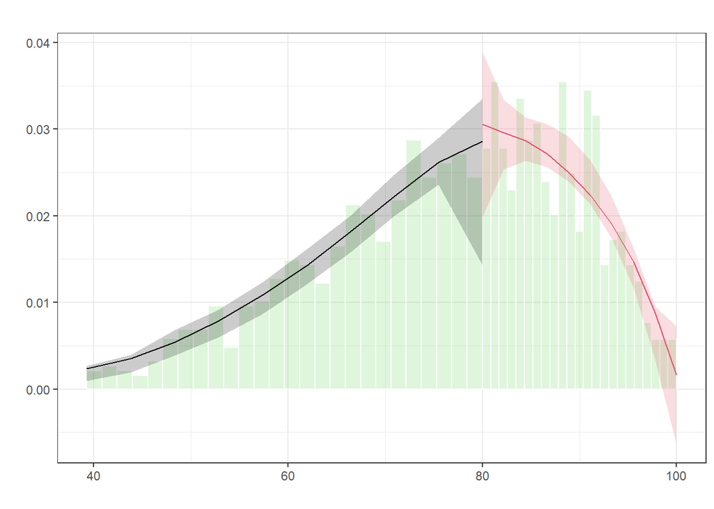

[output not shown]

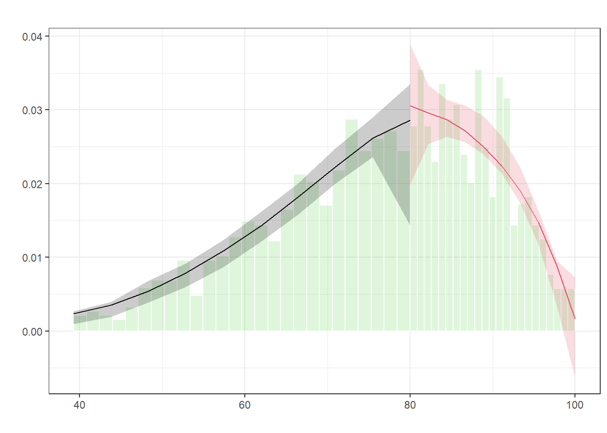

```r
rdplotdensity(rddensity(sillow$performance, c=80), sillow$performance)
```

- 100%: Creates a plot for the density around the cutoff using rdplotdensity and correctly interprets the findings (we will also accept a histogram).
- 80%: Creates a plot for the density around the cutoff, but doesn’t provide a correct interpretation of the results.
- 50%: Explains the potential issue but doesn’t show an appropriate plot.
- 20%: Attempts something that has some meaning, but overall incorrect.
- 0%: Any other case.

### Question 1.6

**Now your boss says they want to roll out this policy for the whole company, so she needs you to estimate an effect for everyone. She suggests fitting a regression of the outcome on the treatment variable and the other covariates in your data. You run the model (because she’s your boss). What do you find when you fit this model? Interpret the coefficient for the treatment variable. How would you explain these results to your boss?** *(Note: Think from a causal inference perspective!)*

```r
lm_all <- lm(sales ~ retreat + performance + age + female, data = sillow)

modelsummary(list(Sales = lm_all), stars = TRUE, gof_omit = 'DF|AIC|BIC|Log.Lik.|F')
```

[output not shown]

*Answer: We find a difference of $59,000 between agents that go to the retreat vs those that don’t, holding other variables constant. We cannot say the retreat coefficient represents a causal effect, because people with worse performance are the ones that attend the retreat, and their poor performance might also be correlated with other variables that affect their sales, and we are not controlling for those characteristics. For example, realtors that attend the retreat could have less initiave, which affected their performance in 2029. At the same time, this same characteristic also affects their sales on the following year, because they are not as proactive as their counterparts.*

- 100%: Fits a multiple regression with treatment and covariates (no interactions). Correctly interprets the coefficient of the treatment variable as an association, and explains why this is not necessarily a causal effect (potential confounding).
- 80%: Fits a multiple regression with treatment and covariates, but includes interactions (kind of emulating an RD). Correctly interprets the coefficient of the treatment variable as an association, and explains why this is not necessarily a causal effect (potential confounding)/ Fits the right model, but doesn’t explain potential confounding threats.
- 50%: Fits a model, but it’s not correct, and doesn’t discuss threats to causality.
- 20%: Attempts something that has some meaning, but overall incorrect.
- 0%: Any other case.

# Task 2: Minimum Wage and Youth Employment (30 points)

We had been discussing the impact of raising minimum wage on employment, but there is a particular group for whom a minimum wage increase can affect greatly: Youth. In this task, we will analyze county-level teen employment rates between 2003 and 2007.

```r
employment <- read.csv("https://raw.githubusercontent.com/maibennett/sta235/main/exampleSite/content/Assignments/Homework/data/hw4/teen_employment.csv")
```

These are the variables we will focus on:

- `year`: The year of the observation
- `countyreal`: Unique identifier for a particular county
- `lpop`: The logarithm of 1000s of population for the county
- `lemp`: The logarithm of teen employment in the county (*Note: No need to transform this variable*)
- `year_mw`: Year when the increase in minimum wage was introduced. If the county did not implement a minimum wage increase, it takes the value 0.

The causal question we are trying to answer in this case is what is the impact of a minimum wage increase on teen employment.

### Question 2.1:

**What are the two dimensions of your differences-in-differences analysis in this case? What is the estimand that you want to estimate**.

*Answer: The two dimensions are time (before or after the mininum wage increase) and states (states that adopted a minimum wage increase vs. those that did not). Because we are using a differences-in-differences approach, the estimand is an Average Treatment Effect on the Treated (ATT), which are the counties that implemented a minimum wage increase between 2003 and 2007.*

- 100%: Correctly identifies the two dimensions and the ATT.
- 50%: Has issues identifying the dimensions or the estimand.
- 20%: Attempts something that has some meaning, but overall incorrect.
- 0%: Any other case.

### Question 2.2:

**Create a `treat` variable that takes the value of 1 for counties that implemented a minimum wage increase between 2003 and 2007 and 0 in another case.** *(Note: The variable treat is at the county level, which means it should be the same for a county regardless of the year)*

*Answer:*

```r
employment <- employment %>% mutate(treat = ifelse(year_mw==0, 0, 1))
```

- 100%: Correctly creates a variable that is 1 for counties that implemented a minimum wage increase within the study period and 0 in other case.
- 50%: Creates a variable that take the value of 1 for the year the county applied the minimum wage increase and 0 in another case.
- 20%: Attempts something that has some meaning, but overall incorrect.
- 0%: Any other case.

### Question 2.3:

**Create a new dataset, `employment_pre`, with only pre-intervention observations (for counties that experienced an increase in minimum wage) and control observations (use the `year_mw` and `year` variable for this). Using the new dataset, compare `lpop` and `lemp` between treated and non-treated counties. What can you conclude from these comparisons? Are these differences a threat to causal inference? Why or why not?**

*Answer: We can see that there are substantial differences between counties that implemented a minimum wage increase (even before the increase) and counties that did not implemented a minimum wage increase between 2003 and 2007. Counties that implemented a minimum wage are significantly larger in population and had a higher rate of teen employment. These differences, however, are not necessarily a threat to causality as long as the parallel trend assumption holds and the difference in population does not differentially affect teen employment over time.*

```r
employment_pre <- employment %>% filter((year<year_mw & treat==1) | treat==0)

employment_pre_bal <- employment_pre %>% select(treat, lpop, lemp)

datasummary_balance(~ treat, data = employment_pre_bal,fmt = 2, title = "Balance Table", dinm_statistic = "p.value")
```

Balance Table

|  | 0 Mean | 0 Std. Dev. | 1 Mean | 1 Std. Dev. | Diff. in Means | p |
| --- | --- | --- | --- | --- | --- | --- |
| lpop | 3.18 | 1.29 | 3.51 | 1.25 | 0.33 | 0.00 |
| lemp | 5.63 | 1.50 | 5.96 | 1.50 | 0.33 | 0.00 |

- 100%: Correctly creates a balance table and shows that there are imbalances. Correctly identifies that these are not necessarily a threat to causality.
- 80%: Doesn’t create the right balance table/has issues creating employment_pre dataset. Correctly identifies that imbalances are not necessarily a threat to causality.
- 50%: Doesn’t create the right balance table/has issues creating employment_pre dataset. Doesn’t mention that imbalances are not necessarily a threat to causality.
- 20%: Attempts something that has some meaning, but overall incorrect.
- 0%: Any other case.

### Question 2.4:

**Fit a staggered difference-in-differences model using the `did` package to analyze the effect of the introduction of a minimum wage increase on `lemp` over time using the `att_gt()` function. Interpret the effect on the year 2007 for counties that implemented a minimum wage increase in 2004.** *Note: You have all the variables you need now defined in your `employment` dataset!*

*Answer: We use the `did` package in this case, and find that for counties that implemented a minimum wage increase in 2004, the estimated average treatment effect of a MW increase for the logarithm of employment is -0.10 in 2007.*

```r
library(did)

dd <- att_gt(yname = "lemp", tname = "year", idname = "countyreal",
             gname = "year_mw", data = employment)

summary(dd)
```

```
##
## Call:
## att_gt(yname = "lemp", tname = "year", idname = "countyreal",
##     gname = "year_mw", data = employment)
##
## Reference: Callaway, Brantly and Pedro H.C. Sant'Anna.  "Difference-in-Differences with Multiple Time Periods." Forthcoming at the Journal of Econometrics <https://arxiv.org/abs/1803.09015>, 2020.
##
## Group-Time Average Treatment Effects:
##  Group Time ATT(g,t) Std. Error [95% Simult.  Conf. Band]
##   2004 2004  -0.0105     0.0227       -0.0723      0.0513
##   2004 2005  -0.0704     0.0326       -0.1590      0.0181
##   2004 2006  -0.1373     0.0399       -0.2457     -0.0289 *
##   2004 2007  -0.1008     0.0345       -0.1946     -0.0070 *
##   2006 2004   0.0065     0.0245       -0.0600      0.0730
##   2006 2005  -0.0028     0.0206       -0.0587      0.0532
##   2006 2006  -0.0046     0.0182       -0.0542      0.0450
##   2006 2007  -0.0412     0.0206       -0.0972      0.0148
##   2007 2004   0.0305     0.0144       -0.0086      0.0696
##   2007 2005  -0.0027     0.0161       -0.0465      0.0411
##   2007 2006  -0.0311     0.0180       -0.0801      0.0180
##   2007 2007  -0.0261     0.0168       -0.0716      0.0195
## ---
## Signif. codes: `*' confidence band does not cover 0
##
## P-value for pre-test of parallel trends assumption:  0.16812
## Control Group:  Never Treated,  Anticipation Periods:  0
## Estimation Method:  Doubly Robust
```

- 100%: Correctly fits the staggered did using att_gt(), and correctly interprets the coefficient, making sure the effect is for the treated counties in the year 2004 (or ATT).
- 80%: Correctly fits the staggered did using att_gt(), but does not necessarily interpret the coefficient correctly in terms of an ATT.
- 50%: Has small issues with the staggered did code and does not necessarily interpret the coefficient correctly.
- 20%: Attempts something that has some meaning, but overall incorrect.
- 0%: Any other case.

### Question 2.5:

**Using your previous results, show the appropriate plot using the `ggdid()` function of the `did` package. What can you say about the pre-trends for the group that implemented a minimum wage increase in 2007? Do you think the parallel trend assumption holds in this case?** *Note: You have all the variables you need now defined in your `employment` dataset!*

*Answer: We can see from the plot below that there is no significant effect for the pre-intervention period for counties that implmented a MW increase in 2007. This means that prior to the introduction of the MW increase, the trends between treated and control states were parallel. This doesn’t assure us that the parallel trend assumption holds, but does give us some evidence that it could be the case.*

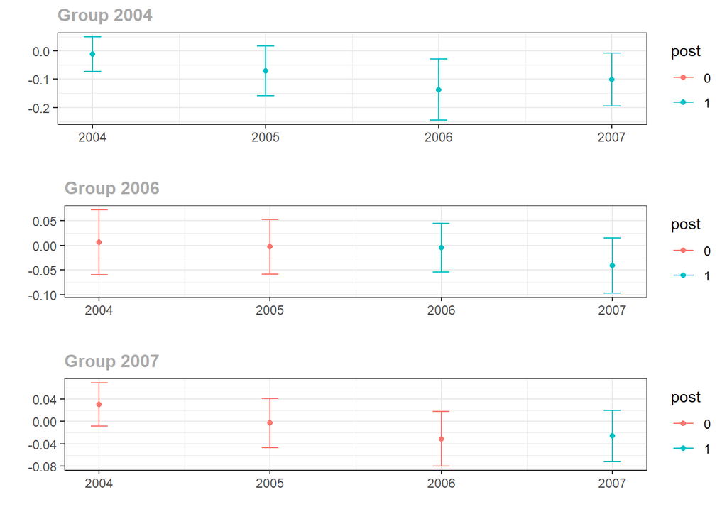

```r
ggdid(dd)
```

- 100%: Generates the right plot and discusses for the group 2007 that the pre-trends seem to hold (confidence bands include 0, so placebo effects are not significant).
- 80%: Generates the right plot, but does not correctly identify that pre-trends are parallel (talks about point estimates but forgets confidence intervals/bands).
- 50%: Doesn’t generate the right plot and has issues with the interpretation.
- 20%: Attempts something that has some meaning, but overall incorrect.
- 0%: Any other case.

# Task 3: Let’s Airbnb (30 points)

In this task, we will be looking at data from Airbnb to analyze how we can better predict price for a rental. In particular, we are interested in finding what the best price for our unit would be based on what’s out there in the market.

```r
airbnb <- read.csv("https://raw.githubusercontent.com/maibennett/sta235/main/exampleSite/content/Assignments/Homework/data/hw4/airbnb.csv")
```

These are some of the variables we are interested in:

- `room_type``: What type of room/unit is rented
- `reviews``: Number of reviews for the place
- `overall_satisfaction`: Rating for the property (from 1-5)
- `accommodates`: How many people it accommodates
- `bedrooms`: Number of bedrooms
- `bathrooms`: Number of bathrooms
- `price`: Price (per night)

For the purpose of all these analyses, only focus on the list of variables given in this description.

### Question 3.1

**We want to compare a simple model for price, only based on bathrooms and number of people that the rental can accommodate vs another model with all the covariates. Without running any analysis, what would be some pros and cons for each of these models?**

*Answer: On one hand, the simple model will have less variance, which means that it will most likely not change as much when I fit it to another dataset. However, if its an over-simplification, then it will probably be high bias as well. On the other hand, the more complex model will most likely better capture the true data generating process, but at the same time, we ran the risk of overfitting our data.*

- 100%: Correctly identifies pros and cons of each model in terms of the bias/variance tradeoff.
- 80%: Has issues with one of the pros and cons of each model.
- 50%: Talks about pros and cons, but not from a bias vs variance perspective/ Gets all the explanations flipped.
- 20%: Attempts something that has some meaning, but overall incorrect.
- 0%: Any other case.

### Question 3.2

**Fit the two previously described models and analyze their accuracy in terms of RMSE using one training and testing dataset. Which one would you prefer and why?**

**Answer: First, we split our data into training and testing datasets and fit the two models (simple and complex). Comparing their RMSE, we can see that the complex model behaves substantially better, with a much lower RMSE, so wwe would choose that one.**

```r
library(modelr)

set.seed(100)

n <- nrow(airbnb)

train <- sample(1:n, n*0.8)

train.data <- airbnb %>% slice(train)

test.data <- airbnb %>% slice(-train)

lm_simple <- lm(price ~ bathrooms + accommodates, data = train.data)

lm_complex <- lm(price ~ factor(room_type) + reviews + overall_satisfaction + bedrooms + bathrooms + accommodates, data = train.data)

rmse(lm_simple, test.data)
```

```
## [1] 106.0046
```

```r
rmse(lm_complex, test.data)
```

```
## [1] 66.39878
```

- 100%: Correctly fits both models in the training dataset, compares the RMSE in the testing dataset, and provides an explanation accordingly.
- 80%: Correctly fits both models in the training dataset, but compares the RMSE in the training dataset. Chooses the one with lowest RMSE.
- 50%: Has issues fitting the models/ doesn’t create a training and testing dataset.
- 20%: Attempts something that has some meaning, but overall incorrect.
- 0%: Any other case.

### Question 3.3

**It doesn’t seem a good idea to just compare two models, so you decide to run a backwards stepwise selection algorithm to choose your model. What is the model you select in this case? Use 5-fold cross-validation in this case. Do you get the same result for forward stepwise selection? What is the RMSE for your backward selection model?** *Note: You will need to create a new dataset with only the variables we discussed in the introduction and no missing values!*

*Answer: We can see that the best model using backwards stepwise selection is the one with 7 variables, that include type of room, reviews, overall satisfaction, how many people accommodates, number of bathrooms and bedrooms. The RMSE for this model is 61.13.*

```r
airbnb_small <- airbnb %>% select(room_type, reviews, overall_satisfaction, accommodates, bedrooms, bathrooms,
                                  price) %>% drop_na()

library(caret)
set.seed(100)

train.control <- trainControl(method = "cv", number = 5) #set up a 10-fold cv

lm.bwd <- train(price ~ ., data = airbnb_small,
                    method = "leapBackward",
                    tuneGrid = data.frame(nvmax = 1:7),
                    trControl = train.control)

lm.bwd$bestTune
```

```
##   nvmax
## 7     7
```

```r
summary(lm.bwd$finalModel)
```

```
## Subset selection object
## 7 Variables  (and intercept)
##                       Forced in Forced out
## room_typePrivate room     FALSE      FALSE
## room_typeShared room      FALSE      FALSE
## reviews                   FALSE      FALSE
## overall_satisfaction      FALSE      FALSE
## accommodates              FALSE      FALSE
## bedrooms                  FALSE      FALSE
## bathrooms                 FALSE      FALSE
## 1 subsets of each size up to 7
## Selection Algorithm: backward
##          room_typePrivate room room_typeShared room reviews
## 1  ( 1 ) " "                   " "                  " "
## 2  ( 1 ) "*"                   " "                  " "
## 3  ( 1 ) "*"                   " "                  " "
## 4  ( 1 ) "*"                   "*"                  " "
## 5  ( 1 ) "*"                   "*"                  "*"
## 6  ( 1 ) "*"                   "*"                  "*"
## 7  ( 1 ) "*"                   "*"                  "*"
##          overall_satisfaction accommodates bedrooms bathrooms
## 1  ( 1 ) " "                  " "          "*"      " "
## 2  ( 1 ) " "                  " "          "*"      " "
## 3  ( 1 ) " "                  " "          "*"      "*"
## 4  ( 1 ) " "                  " "          "*"      "*"
## 5  ( 1 ) " "                  " "          "*"      "*"
## 6  ( 1 ) "*"                  " "          "*"      "*"
## 7  ( 1 ) "*"                  "*"          "*"      "*"
```

```r
lm.bwd$results
```

```
##   nvmax     RMSE  Rsquared      MAE   RMSESD RsquaredSD    MAESD
## 1     1 65.90340 0.3669151 42.31375 5.728272 0.01653576 1.491925
## 2     2 63.67663 0.4093491 38.37366 6.005720 0.02240157 1.370671
## 3     3 62.54761 0.4297542 37.36771 5.765306 0.01887414 1.469826
## 4     4 61.67006 0.4456481 36.75719 5.968788 0.02437261 1.546678
## 5     5 61.31315 0.4522106 36.84231 5.967505 0.02541298 1.483458
## 6     6 61.14215 0.4553199 36.61849 6.024489 0.02641725 1.507513
## 7     7 61.13143 0.4555101 36.46589 5.997895 0.02614533 1.512830
```

When we do the same algorithm but forward, we get the same result.

```r
lm.fwd <- train(price ~ ., data = airbnb_small,
                    method = "leapForward",
                    tuneGrid = data.frame(nvmax = 1:7),
                    trControl = train.control)

lm.fwd$bestTune
```

```
##   nvmax
## 7     7
```

```r
summary(lm.fwd$finalModel)
```

```
## Subset selection object
## 7 Variables  (and intercept)
##                       Forced in Forced out
## room_typePrivate room     FALSE      FALSE
## room_typeShared room      FALSE      FALSE
## reviews                   FALSE      FALSE
## overall_satisfaction      FALSE      FALSE
## accommodates              FALSE      FALSE
## bedrooms                  FALSE      FALSE
## bathrooms                 FALSE      FALSE
## 1 subsets of each size up to 7
## Selection Algorithm: forward
##          room_typePrivate room room_typeShared room reviews
## 1  ( 1 ) " "                   " "                  " "
## 2  ( 1 ) "*"                   " "                  " "
## 3  ( 1 ) "*"                   " "                  " "
## 4  ( 1 ) "*"                   "*"                  " "
## 5  ( 1 ) "*"                   "*"                  "*"
## 6  ( 1 ) "*"                   "*"                  "*"
## 7  ( 1 ) "*"                   "*"                  "*"
##          overall_satisfaction accommodates bedrooms bathrooms
## 1  ( 1 ) " "                  " "          "*"      " "
## 2  ( 1 ) " "                  " "          "*"      " "
## 3  ( 1 ) " "                  " "          "*"      "*"
## 4  ( 1 ) " "                  " "          "*"      "*"
## 5  ( 1 ) " "                  " "          "*"      "*"
## 6  ( 1 ) "*"                  " "          "*"      "*"
## 7  ( 1 ) "*"                  "*"          "*"      "*"
```

- 100%: Correctly removes missing values from the dataset, and fits both forward and backwards subsetting using 5-fold cross-validation (they can fit in with the entire dataset). They use the right amount of variables in nvmax (7). Show the correct RMSE in the testing dataset.
- 80%: Have issues with one of the following: (i) removing missing values from the dataset, (ii) doesn’t fit backwards subsetting, (iii) doesn’t use 5-fold CV, (iv) doesn’t use the right amount of nvmax, or (v) doesn’t show the right RSME.
- 50%: Have issues with two of the previous tasks.
- 20%: Attempts something that has some meaning, but overall incorrect.
- 0%: Any other case.

### Question 3.4

**You are trying to figure out the price for your rental, and have decided that if the price is under $100 a night, then it’s probably not worth it to list it on Airbnb. Using the previous dataset from 3.3, create a binary variable that takes the value of 1 if the price is $100 or more, and 0 in another case. Fit a logistic regression using room type, reviews, accommodates, bedrooms, bathrooms, and overall satisfaction. Interpret the coefficient for `accommodates` and `room_type` (private room) in terms of odds. Do these coefficients play a significant role in prediction?**

*Answer: As we can see from the table below, one additional person that we can accommodate in the rental is associated with a 1.12 times increase on average in the odds of the price being over $100 vs being under, holding other variables constant. Interpreting now the coefficient for private room, we can see that the odds of the place having a value of $100 or more are 0.14 times the odds of having a value over $100 if the rental is the entire apartment, holding other variables constant.*

```r
airbnb_small <- airbnb_small %>% mutate(over100 = ifelse(price>=100, 1, 0))

logit <- glm(over100 ~ room_type + reviews + accommodates + bedrooms + bathrooms +
               overall_satisfaction,
             family = binomial(link = "logit"),
              data = airbnb_small)

modelsummary(list("Over $100" = logit), stars = TRUE, gof_omit = 'DF|AIC|BIC|Log.Lik.|F')
```

|  | Over $100 |
| --- | --- |
| (Intercept) | -5.173*** |
|  | (0.605) |
| room_typePrivate room | -1.943*** |
|  | (0.112) |
| room_typeShared room | -19.365 |
|  | (205.892) |
| reviews | -0.005*** |
|  | (0.001) |
| accommodates | 0.113*** |
|  | (0.030) |
| bedrooms | 0.803*** |
|  | (0.065) |
| bathrooms | 0.988*** |
|  | (0.095) |
| overall_satisfaction | 0.547*** |
|  | (0.122) |
| Num.Obs. | 6101 |

+ p < 0.1, * p < 0.05, ** p < 0.01, *** p < 0.001

- 100%: Correctly creates the outcome variable and fits the right model. Exponentiates the coefficient and correctly interprets it in terms of odds.
- 80%: Has an issue fitting the model or with the interpretation (e.g. doesn’t use correct language, interprets it as probabilities, doesn’t hold variables constant, etc.)
- 50%: Have issues with two of the previous tasks.
- 20%: Attempts something that has some meaning, but overall incorrect.
- 0%: Any other case.

### Question 3.5

**You are thinking of buying a new pull-out couch, so your place can fit one more person. Using your previous results from 3.4, estimate the difference in probability of accommodating one additional person (going from 3 to 4) on having a listing over $100 for an entire home for a rental with: 2 bedrooms and 1 bathroom, an overall satisfaction rating of 4 and 10 reviews? How does it compare for the change in probability of going from a 4 to a 5 star rating (overall satisfaction), and keeping an accommodation for 3 for the same rental?**

*Answer: As we can see, there is an increase in probability of 2.8 percentage points of accommodating 4 instead of 3 people for the described rental for the price being over $100. The estimated difference of going from a 4 to a 5 star rating, though, for the same rental accommodating 3 people, on having a nightly price for $100 or more is 13.5 percentage points.*

```r
preds1 <- predict(logit, newdata = data.frame("room_type" = c("Entire home/apt", "Entire home/apt"),
                                             "accommodates" = c(3, 4),
                                             "bedrooms" = c(2,2),
                                             "bathrooms" = c(1,1),
                                             "overall_satisfaction" = c(4,4),
                                             "reviews" = c(10,10)),
                            type = "response")

preds1
```

```
##         1         2
## 0.4731702 0.5014751
```

```r
diff(preds1)
```

```
##          2
## 0.02830486
```

```r
preds2 <- predict(logit, newdata = data.frame("room_type" = c("Entire home/apt", "Entire home/apt"),
                                             "accommodates" = c(3, 3),
                                             "bedrooms" = c(2,2),
                                             "bathrooms" = c(1,1),
                                             "overall_satisfaction" = c(4,5),
                                             "reviews" = c(10,10)),
                            type = "response")

preds2
```

```
##         1         2
## 0.4731702 0.6080463
```

```r
diff(preds2)
```

```
##        2
## 0.134876
```

- 100%: Creates the correct dataframes (with the specified characteristics) to assess the change in probability from going from accommodating 3 to 4 people, and changing rating from 4 to 5. Obtains the right predicted probailities and interprets their results correctly.
- 80%: Has issues with one of the following: (i) creating the datasets according to the specified characteristics, (ii) fitting probabilities (e.g. uses the log odds), or (iii) doesn’t get the difference in probabilities for the two cases.
- 50%: Have issues with two of the previous tasks.
- 20%: Attempts something that has some meaning, but overall incorrect.
- 0%: Any other case.